# 统计软件第1次作业

请各位同学严格按照以下要求提交，否则酌情扣分。

1、请将你的html文件命名为：姓名_学号_统计软件第1次作业。

2、展示你的代码、输出结果和相应的注释（代码一定要有注释！注释！注释！）

3、凡迟交或不交作业或命名不正确的，本次作业将有相应扣分。

## 任务一：

在很多实际数据中，有些日期的表示并不是yyyy-mm-dd的形式，极个别情况是以数字形式展示，比如某实际数据中用20219代表日期，请将该数值转化成日期形式。提示：可以搜索下这是因为什么？然后给出在R中的解决办法，你可能的输出会是下面这样。

```
## [1] "2025-05-11"
```

## 任务二：

请计算课堂上的示例数据“电影数据.csv”中“夜孔雀”和“叶问3”上映时间相差多少天

```
## Time difference of 77 days
```

## 任务三：

以下任务三到任务六全部基于数据film.csv完成。该数据集收集了中国电影发行放映协会统计的2010-2013年票房过千万的电影数据，共275个样本。变量说明如下表所示（注意：放映场数和人数做过数学变换，但不影响具体分析）

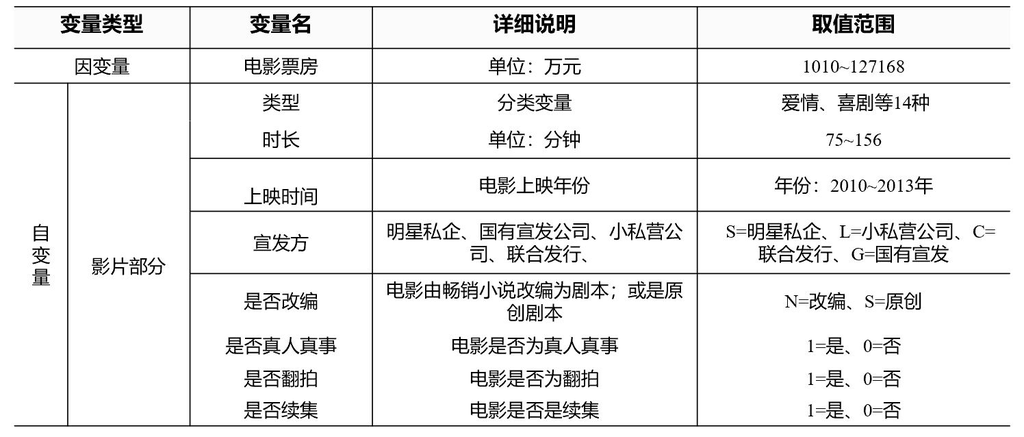

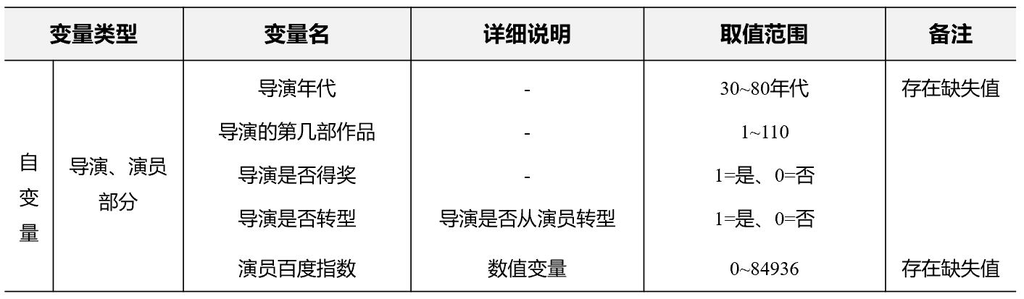

- 读入film.csv数据集，将其命名为a，尝试使用summary函数查看数据总体情况。
- 重点查看缺失情况，如果有缺失，请将缺失数据所在行全部删掉（提示：你可能需要搜索一些处理缺失数据的函数）
- 展示票房最高和最低记录的观测。

```
##              片名 放映场数    人数 电影票房 类型 上映年份 上映月份 上映周数
## 53 人再囧途之泰囧   833.71 3920.55 127168.1 喜剧     2012       12       51
##    宣发方 时长 是否改编 是否真人真事 是否翻拍 是否续集 导演 导演年代 第几部作品
## 53      S  105        S            0        0        1 徐峥       70          1
##    导演得奖情况 导演是否转型 主演1 baidu.index1 主演2 baidu.index2
## 53            1            1  徐峥         3770  黄渤         9285
```

```
##                           片名 放映场数 人数 电影票房 类型 上映年份 上映月份
## 220 举起手来（之二）追击阿多丸    20.24 41.3  1010.16 喜剧     2010        9
##     上映周数 宣发方 时长 是否改编 是否真人真事 是否翻拍 是否续集   导演
## 220       37      G   91        S            0        0        1 冯小宁
##     导演年代 第几部作品 导演得奖情况 导演是否转型  主演1 baidu.index1 主演2
## 220       50         13            1            0 潘长江         2639  郭达
##     baidu.index2
## 220          857
```

## 任务四：

- 根据上映月份新生成一个变量叫做dangqi，其中12月、1月和2月归为贺岁档；7、8、9归为暑期档；3、4归为普通档；5、6归为黄金1档；10、11归为黄金2挡；最后对档期进行统计（提示：你可能需要用到table函数）

```
##
##  贺岁档 黄金1档 黄金2档  普通档  暑期档
##      66      35      33      42      90
```

## 任务五：

- 将导演年代为30和40的统一合并为“50以下”
- 合并之后，更改导演年代的因子水平，使其变为：50以下<60<70<80

## 任务六：

- 新生成一个变量叫做“上映日期”，由“上映年份”和“上映月份”构成，日期统一用每月的1号。例如新天生一对的上映日期为2012-01-01。
- 将数据集按照上映日期、票房和类型进行排序，其中上映日期升序排序、票房降序排序。展示前10行。